# Homework 4 Solutions

Biostatistics 735/794

Alexander McLain

2025-12-04

```r
library(tidyverse)
library(kableExtra)
library(scales)
library(FactoMineR)
library(factoextra)
library(psych)
library(fastICA)
# MDS
library(stats)

# t-SNE & UMAP
library(Rtsne)

# Plotting helpers
library(ggrepel)
# for question 5
library(ISLR)
library(cluster)
library(mclust)
library(EMCluster) #for the rand functions
library(NbClust)
library(fpc)
library(GGally)
library(knitr)

# Small helper: nice tables
kbl2 <- function(x, ...) kable(x, align = "lrrrrrr", ...) %>% kable_styling(full_width = FALSE)
```

# 1. Global versus Local Structure

**(20 points)** You are studying a dataset of 500 patients, each with 200 biomarkers measured at baseline. You plan to visualize the relationships between individuals using a low-dimensional embedding (2D or 3D). Consider the following situations and state whether a **global** or **local** dimension reduction method would be more appropriate. Justify your answer in 2–3 sentences.

1. You believe there is a single underlying continuous “disease severity” score that explains most of the biomarker variation.

Because the goal is to uncover a single latent “disease severity” construct that drives the biomarker patterns across all patients, a **global dimension reduction method** is most appropriate. Global methods (e.g., PCA, factor analysis) capture the dominant sources of variation in the entire dataset and can reveal overarching continuous scores that summarize overall severity.

2. You are interested in identifying small subgroups of patients with very similar biomarker profiles but distinct from the rest of the population.

Here the goal is to detect **small, homogeneous subgroups** of patients who differ from the rest of the population, so a **local dimension reduction method** is more suitable. Local methods (e.g., UMAP, t-SNE, Isomap) preserve neighborhood structure and emphasize local similarities, making them effective for revealing subtle clusters that global methods may smooth over.

3. You plan to create a 2D visualization of single-cell RNA expression data to identify cell-type clusters.

For visualizing single-cell RNA-seq data and identifying cell-type clusters, a **local dimension reduction method** such as t-SNE or UMAP is appropriate. These methods preserve fine-grained local relationships and therefore allow biologically similar cells to cluster together in low-dimensional space, whereas global methods often miss these subtle but important boundaries.

4. You have time-series physiological data (e.g., heart rate, sleep, and activity) and want to summarize the overall level and variability across participants.

If the goal is to summarize broad patterns–such as overall levels and variability in time-series physiological measures across participants–a **global dimension reduction method** is most appropriate. Global methods highlight major sources of variation shared across the dataset and provide low-dimensional summaries of overall behavior rather than focusing on small local deviations.

# 2. Dimension Reduction Key Details

**(20 points)** Complete the table below by summarizing the key ideas for each dimension reduction method.

| Method | Main.Objective | When.to.Use…Key.Characteristics |
| --- | --- | --- |
| PCA | Find new orthogonal directions that capture the maximum variance in the data. | Use when the goal is global dimension reduction; components are uncorrelated and ordered by explained variance; best for summarizing overall structure. |
| Factor Analysis | Identify a smaller set of latent factors that explain shared variation among observed variables. | Use when you believe underlying latent constructs drive the correlations among variables; focuses on shared (common) variance rather than total variance. |
| ICA | Decompose the data into statistically independent source signals. | Use when observed data are mixtures of independent underlying sources; assumes statistical independence; useful for signal separation problems. |
| t-SNE | Create a low-dimensional representation that highlights local structure and cluster separation. | Use for visualizing complex, high-dimensional data; preserves local neighborhoods; highly effective for revealing clusters; sensitive to tuning parameters (e.g., perplexity). |
| UMAP | Preserve both local and some global structure while producing a low-dimensional embedding for visualization or clustering. | Use for clustering or visualization; preserves local neighborhoods while maintaining some global structure; flexible with distance metrics; often faster and more stable than t-SNE. |

# 3. Dimension Reduction on Economic Data

**(30 points)** In this exercise, you will analyze country-level global health indicators from the gapminder dataset. This dataset contains country-level statistics including GDP, per capita, life expectancy, and population size from 1952–2007.

Step 1: Load the data.

```r
# Install/load packages
#install.packages("gapminder")
library(gapminder)
data(gapminder)
# Subset the most recent year
gap <- subset(gapminder, year == 2007)
# Keep quantitative variables only
gap_sub <- data.frame(gap[, c("lifeExp", "gdpPercap", "pop")])
rownames(gap_sub) <- gap$country
```

Step 2: Dimension Reduction Tasks

1. Perform a Principal Component Analysis (PCA) on the standardized variables. Report the proportion of variance explained by each component and create a biplot showing countries colored by continent.

I’m going to log transform the variables before performing the PCA.

```r
gap_tr <- gap_sub %>%
  mutate(across(where(is.numeric), \(x) log(x + 1))) %>%
  as_tibble()


#PCA on standardized variables
pca_gap <- prcomp(gap_tr, center = TRUE, scale = TRUE)
# Variance explained
var_explained <- pca_gap$sdev^2 / sum(pca_gap$sdev^2)
cum_var <- cumsum(var_explained)

tibble(var_explained, cum_var) %>% kbl2(digits = 3)
```

| var_explained | cum_var |
| --- | --- |
| 0.594 | 0.594 |
| 0.336 | 0.930 |
| 0.070 | 1.000 |

```r
# Extract loadings (rotation matrix)
pca_loadings <- as.data.frame(pca_gap$rotation)

# Add variable names as a column
pca_loadings <- tibble::rownames_to_column(pca_loadings, var = "Variable")

pca_loadings %>% kbl2(digits = 3)
```

| Variable | PC1 | PC2 | PC3 |
| --- | --- | --- | --- |
| lifeExp | -0.708 | -0.057 | 0.704 |
| gdpPercap | -0.706 | 0.091 | -0.702 |
| pop | -0.024 | -0.994 | -0.105 |

```r
summary(pca_gap)
```

```
## Importance of components:
##                           PC1    PC2     PC3
## Standard deviation     1.3345 1.0042 0.45896
## Proportion of Variance 0.5937 0.3361 0.07021
## Cumulative Proportion  0.5937 0.9298 1.00000
```

The PCA reduces three variables into two main dimensions that explain $93\%$ of the variability. PC1 explains $59.4\%$ percent of the variance while PC2 explains 33.6% of the variance. PC1 has a strong negative relationship with GDP and life expectancy, where larger values lead to larger negative PC1 scores. PC2 is almost strictly a function of the population size.

```r
#biplot showing countries colored by continent
gap_tr$continent <- factor(gap$continent)


K <- which(cum_var >= 0.90)[1]
cat("Keeping", K, "components explains ≥90% of variance.\n")
```

```
## Keeping 2 components explains ≥90% of variance.
```

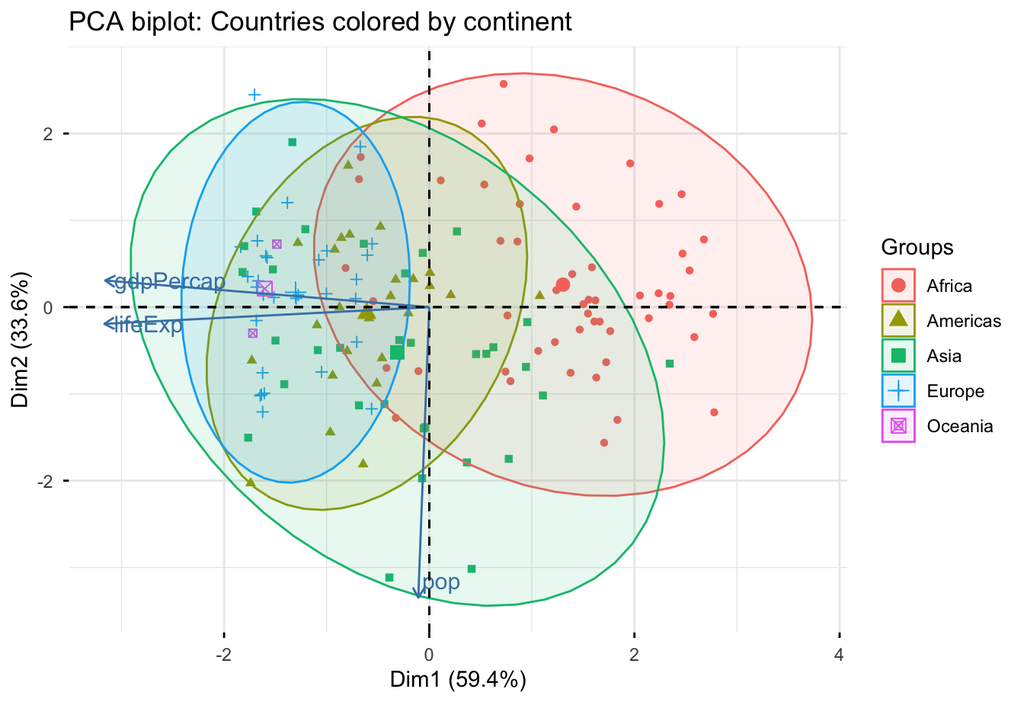

```r
X_pca_auto <- as.data.frame(pca_gap$x[, 1:K])

fviz_pca_biplot(
  pca_gap,
  geom.ind = "point",
  habillage = gap_tr$continent,
  addEllipses = TRUE,
  repel = TRUE,
  label = "var"   # "var" draws variable labels (arrows + names); use "none" to hide them
) +
  labs(title = "PCA biplot: Countries colored by continent")
```

2. Conduct a Factor Analysis with two latent factors. Interpret what each factor appears to represent in terms of economic and health dimensions.

```r
gap_tr <- gap_tr %>% dplyr::select(-continent)
# KMO > 0.6 is acceptable; closer to 1 is better
psych::KMO(gap_tr)
```

```
## Kaiser-Meyer-Olkin factor adequacy
## Call: psych::KMO(r = gap_tr)
## Overall MSA =  0.48
## MSA for each item =
##   lifeExp gdpPercap       pop
##      0.49      0.49      0.11
```

```r
cor(gap_tr) %>% kbl2(digits = 3)
```

|  | lifeExp | gdpPercap | pop |
| --- | --- | --- | --- |
| lifeExp | 1.000 | 0.781 | 0.072 |
| gdpPercap | 0.781 | 1.000 | -0.046 |
| pop | 0.072 | -0.046 | 1.000 |

```r
# Bartlett's test (tests whether correlation matrix differs from identity)
cortest.bartlett(cor(gap_tr), n = nrow(gap_sub))
```

```
## $chisq
## [1] 135.2833
##
## $p.value
## [1] 3.929617e-29
##
## $df
## [1] 3
```

The correlation between life expectancy and per capita GDP is clearly significant, but there are not enough variables here to do a full (proper) factor analysis.

```r
set.seed(165465)
fa_gap <- fa(gap_tr, nfactors = 2, rotate = "varimax", fm = "ml")

print(fa_gap, sort = TRUE)
```

```
## Factor Analysis using method =  ml
## Call: fa(r = gap_tr, nfactors = 2, rotate = "varimax", fm = "ml")
## Standardized loadings (pattern matrix) based upon correlation matrix
##           item  ML1   ML2    h2     u2 com
## gdpPercap    2 0.96 -0.26 0.990 0.0098 1.1
## lifeExp      1 0.92  0.39 0.991 0.0092 1.3
## pop          3 0.00  0.18 0.033 0.9668 1.0
##
##                        ML1  ML2
## SS loadings           1.76 0.25
## Proportion Var        0.59 0.08
## Cumulative Var        0.59 0.67
## Proportion Explained  0.88 0.12
## Cumulative Proportion 0.88 1.00
##
## Mean item complexity =  1.2
## Test of the hypothesis that 2 factors are sufficient.
##
## df null model =  3  with the objective function =  0.97 with Chi Square =  135.28
## df of  the model are -2  and the objective function was  0
##
## The root mean square of the residuals (RMSR) is  0
## The df corrected root mean square of the residuals is  NA
##
## The harmonic n.obs is  142 with the empirical chi square  0  with prob <  NA
## The total n.obs was  142  with Likelihood Chi Square =  0  with prob <  NA
##
## Tucker Lewis Index of factoring reliability =  1.023
## Fit based upon off diagonal values = 1
## Measures of factor score adequacy
##                                                    ML1  ML2
## Correlation of (regression) scores with factors   1.00 0.98
## Multiple R square of scores with factors          0.99 0.96
## Minimum correlation of possible factor scores     0.99 0.91
```

The factor analysis extracted two latent factors, but the results suggest that only the first factor is meaningful.

- Factor 1 (ML1) shows extremely strong loadings on GDP per capita (0.96) and life expectancy (0.92), indicating a clear underlying socioeconomic well-being dimension.
- Factor 2 (ML2) does not have substantial loadings on any variable (all loadings < 0.40), suggesting it does not capture a distinct or interpretable construct.

The communalities reinforce this interpretation: GDP per capita and life expectancy have very high communalities (~0.99), meaning they are almost entirely explained by Factor 1. In contrast, population has a very low communality (~0.03), indicating that it is largely unrelated to the extracted factors. The complexity values (near 1) also show that GDP per capita and life expectancy load cleanly on a single factor, while population contributes very little to either factor.

Overall, the solution supports a single-factor structure, with Factor 1 reflecting a strong socioeconomic dimension and Factor 2 offering no meaningful additional information.

3. Perform an Independent Component Analysis (ICA) with two components. Compare the ICA components to the PCA loadings and discuss differences in interpretation.

```r
set.seed(2132131)
ica_gap <- fastICA(gap_tr, n.comp = 2)

ica_scores <- data.frame(ica_gap$S, gap_tr)

# Rename ICA components properly
colnames(ica_scores)[1:2] <- paste0("IC", 1:2)

# Check results
head(ica_scores) %>% kbl2(digits = 3)
```

| IC1 | IC2 | lifeExp | gdpPercap | pop |
| --- | --- | --- | --- | --- |
| -0.451 | -1.359 | 3.803 | 6.883 | 17.278 |
| 0.760 | 0.152 | 4.349 | 8.689 | 15.097 |
| -0.700 | 0.017 | 4.295 | 8.736 | 17.322 |
| -0.013 | -0.140 | 3.778 | 8.476 | 16.335 |
| -0.906 | 0.526 | 4.335 | 9.456 | 17.512 |
| -0.575 | 1.299 | 4.410 | 10.447 | 16.833 |

```r
# Inspect loadings (mixing matrix)
ica_loadings <- t(ica_gap$A)
ica_loadings %>% kbl2(digits = 3)
```

| -0.038 | 0.149 |
| --- | --- |
| -0.149 | 1.342 |
| -1.502 | -0.237 |

Let’s compare these with the ICA components to the PCA loadings.

```r
cbind(pca_loadings[,2:3],ica_loadings) %>% kbl2(digits = 3)
```

| PC1 | PC2 | 1 | 2 |
| --- | --- | --- | --- |
| -0.708 | -0.057 | -0.038 | 0.149 |
| -0.706 | 0.091 | -0.149 | 1.342 |
| -0.024 | -0.994 | -1.502 | -0.237 |

The PCA loadings and ICA components highlight very different ways of decomposing the same data.

PCA loadings (PC1 and PC2) reflect directions of maximum variance in the data and are constrained to be orthogonal.

• PC1 loads almost equally on life expectancy and GDP per capita (both around –0.70), indicating a global socioeconomic gradient.

• PC2 loads almost entirely on population (–0.99), separating countries by size rather than socioeconomic status.

PCA therefore gives interpretable, variance-based components that summarize broad structure.

ICA components (IC1 and IC2) instead attempt to extract statistically independent signals, with no constraints on variance or orthogonality.

• IC1 loads extremely strongly on population (–1.50), suggesting an independent “population size” source signal distinct from the others.

• IC2 loads strongly on GDP per capita (1.34), separating economic levels independently of the other variables.

• Life expectancy has only weak loadings in ICA, implying it does not form a statistically independent source in this dataset.

In short, PCA identifies axes of shared variance, producing smooth, blended components, while ICA isolates independent source signals, which can lead to much sharper, more extreme loadings. PCA components are easier to interpret as global patterns, whereas ICA components represent independent, latent generating mechanisms that may not align with simple socioeconomic gradients.

4. Apply both t-SNE and UMAP with two dimensions. For each approach, create a scatterplot for each method with points colored by continent. UMAP is supposed to represent more global vs. local structure than t-SNE. Do the results appear to back this statement up? Why?

```r
set.seed(8675309)
#t-SNE
tsne_fit <- Rtsne(gap_tr, dims = 2, perplexity = 40, verbose = FALSE)

# combine t-SNE coordinates with identifiers
tsne_scores <- data.frame(
  Dim1 = tsne_fit$Y[, 1],
  Dim2 = tsne_fit$Y[, 2],
  country = gap$country,
  continent = gap$continent
)
```

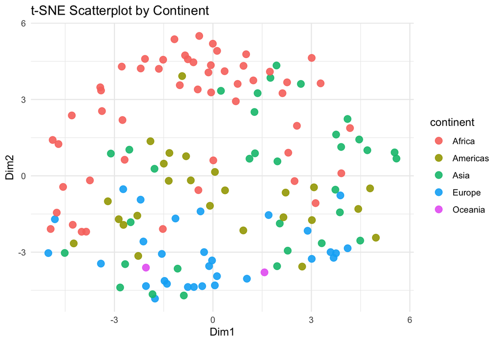

```r
ggplot(tsne_scores, aes(x = Dim1, y = Dim2, color = continent)) +
  geom_point(size = 3, alpha = 0.9) +
  theme_minimal() +
  labs(title = "t-SNE Scatterplot by Continent")
```

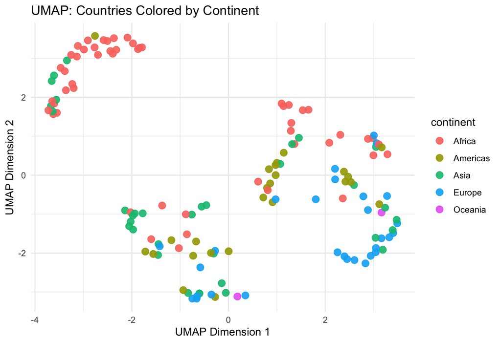

```r
#UMAP
set.seed(8675309)
umap_fit <- uwot::umap(
  as.matrix(gap_tr))

umap_scores <- data.frame(
  Dim1 = umap_fit[, 1],
  Dim2 = umap_fit[, 2],
  country = gap$country,
  continent = gap$continent
)


# plot
ggplot(umap_scores, aes(x = Dim1, y = Dim2, color = continent)) +
  geom_point(size = 3, alpha = 0.9) +
  theme_minimal() +
  labs(
    title = "UMAP: Countries Colored by Continent",
    x = "UMAP Dimension 1",
    y = "UMAP Dimension 2"
  )
```

The UMAP results suggest three fairly distinct clusters of countries. One cluster (top left) consists primarily of African countries, with a few from Asia. The other two clusters contain a mixture of countries from multiple continents, though the cluster on the far right may itself contain two subgroups. In contrast, the t-SNE embedding does not reveal a strong overall clustering structure. African countries tend to have higher values on Dimension 2, while many European countries fall on the lower (more negative) end, but Dimension 1 shows no clear relationship with continent membership.

5. Include one paragraph comparing PCA, FA, ICA, t-SNE, and UMAP for this dataset.

Across the economic dataset, the five dimension-reduction methods reveal different aspects of structure in the variables.

- PCA produces a clear global pattern in which GDP per capita and life expectancy load strongly onto the first principal component, reflecting a dominant socioeconomic gradient, while population largely defines the second component.
- Factor Analysis yields a similar conclusion: a single strong latent factor explains nearly all shared variation in GDP per capita and life expectancy, with population showing little connection to the latent structure.
- ICA, by contrast, separates the data into statistically independent signals—one driven almost entirely by population size and another dominated by GDP per capita—highlighting independent sources rather than shared patterns.
- The nonlinear methods emphasize local structure: UMAP identifies three visually distinct clusters of countries, including a group composed mostly of African nations and two mixed clusters, one of which may have internal subgroups. t-SNE, however, does not produce clear clusters but does show a gradient on its second dimension, with African countries scoring higher and European countries scoring lower.

Together, these methods illustrate how global techniques (PCA, FA) capture broad socioeconomic trends, ICA isolates independent sources, and local nonlinear methods (t-SNE, UMAP) explore fine-grained or regional structure in the dataset.

# 4. Conceptual and Comparative

**(15 points)** Complete the table below comparing the following clustering methods.

| Method | Criterion | Strengths | Limitations |
| --- | --- | --- | --- |
| K-Means | Minimizes the total within-cluster sum of squares using Euclidean distance. | Fast and scalable; works well for continuous data with roughly spherical clusters. | Assumes spherical, equal-variance clusters; sensitive to outliers and initialization; numeric data only. |
| Gaussian Mixture Model (GMM) | Uses cluster membership probabilities; EM algorithm estimates parameters by maximizing the likelihood. | Flexible—can model overlapping and elliptical clusters; provides soft (probabilistic) assignments. | Relies on distributional assumptions; can be sensitive to initialization and number of components. |
| PAM (Partitioning Around Medoids) | Clusters around medoids (actual observations) rather than means. | Robust to outliers; works with mixed data types and any distance metric; interpretable cluster centers. | Slower on large datasets because distances to all medoids must be computed. |
| Hierarchical Clustering | Builds clusters based on pairwise dissimilarities using linkage methods (single, complete, average, etc.). | Useful for exploring structure; produces a full dendrogram; does not require choosing K in advance. | Computationally expensive for large datasets; choice of linkage and distance metric affects results. |